# Étude territoriale

Chiara Coppa

10/22/2022

## Introduction

La région d’étude sur laquelle est basée cette étude territoriale est composée par deux districts suisses. Le premier est le district de Muri dans le canton d’Argovie et le deuxième est le district d’Affoltern dans le canton de Zurich. Les deux districts se trouvent à la frontière entre leurs deux cantons. Ces régions d’étude sont visibles sur la carte de situation suivante.

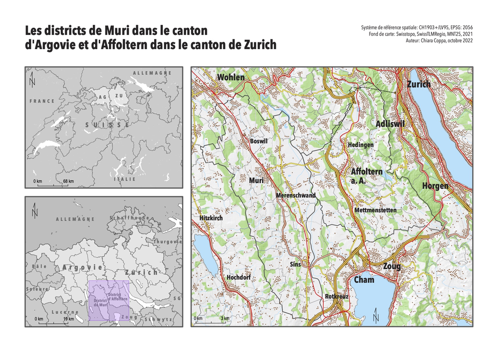

Tout d’abord, la carte en haut à gauche montre la position des deux cantons (Argovie et Zurich) par rapport à la Suisse. La deuxième en bas à gauche permet de voir où se trouvent les deux districts (Muri et Affoltern) par rapport aux cantons. Ensuite dans la troisième carte, on peut voir les territoires des deux districts au niveau topographique.

Le district de Muri est composé de 19 communes. Selon la typologie des communes définie en 2012 par l’Office fédéral de la statistique (OFS, 2012), visible sur la carte en bas, cinq de ces communes (situés à ouest du district) sont classés comme *commune rurale en situation centrale*. La commune de Muri est classée comme *commune d’un centre rural* (vert foncé) tandis que les autres communes sont des *communes périurbaines de faible à moyenne densité*.

[figure not shown]

Figure 2: Carte de la typologie des communes (OFS, 2012)

Le district possède une population de 37’967 habitants à la fin du 2021 et sa surface est de 138,95 km2. Sa densité est donc de 273,2 habitants par km2 (qu’au niveau des surfaces productives devienne 280,2 hab/km2) (OFS, 2021).

Le relief du district n’est pas marqué, il présente une grande surface centrale assez plate, remplie de champs agricoles, seulement la partie à ouest-sud-ouest du district s’élève légèrement en altitude (Figure 3).

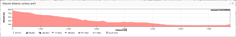

Figure 3: Relief district de Muri (https://map.geo.admin.ch))

Le district d’Affoltern est composé de 14 communes dont deux sont classées comme *commune urbaine d’une grande agglomération*. Les autres sont des *communes périurbaines de faible à forte densité* (OFS, 2012) (Figure 2). La population est plus importante de l’autre district, elle vaut 56’370 habitants (en 2021) sur une surface plus restreinte de 113,03 km2. Cela produit une densité plus élevée qui équivaut à 498,7 hab/km2 (qui devienne 512,5 si on considère que la surface productive) (OFS, 2021). Par rapport au district de Muri, Affoltern est plus urbaine au niveau des communes.

Le relief d’Affoltern est un peu plus marqué, surtout dans la partie est-nord-est du district (Figure 4).

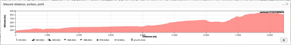

Figure 4: Relief district d’Affoltern (https://map.geo.admin.ch))

Au niveau de la mobilité, comme on peut voir dans la carte de situation (Figure 1), le district d’Affoltern est traversé par l’autoroute et une route d’importance régionale (Swisstopo, 2022). Le district de Muri, au contraire, n’as pas d’accès directe à l’autoroute et elle n’est pas présente sur le territoire que pour une partie au sud. Cependant, Muri est traversé par une route de *transit importante* et une *d’importance régionale* (Swisstopo, 2022). Les deux districts sont aussi traversés par le chemin de fer.

La thématique sur laquelle se base cette étude de territoire est celle de comprendre la répartition de la surface agricole utile (SAU) dans les deux districts précédemment décrits et les confronter aux leurs cantons respectifs (Argovie et Zurich).

La surface agricole utile *“est une notion normalisée dans la statistique agricole européenne. Elle comprend les terres arables (y compris pâturages temporaires, jachères, cultures sous abri, jardins familiaux…), les surfaces toujours en herbe et les cultures permanentes (vignes, vergers…)”* (Insee, 2020). Puisque, comme décrit avant, les deux districts sont assez rurales et ils possèdent des plaines propices à l’agriculture, on peut étudier si ces espaces sont exploités majoritairement par rapport aux moyennes cantonales. En plus, les deux districts se situent dans le Plateau Suisse, où on trouve presque la moitié des surfaces agricoles de la Suisse (Présence Suisse, 2021). L’étude essayera donc de comprendre l’importance dans les districts des surfaces agricoles utiles en comparaison avec leurs cantons.

## Bibliographie:

Insee (2020). Superficie agricole utilisée / SAU. Institue national de la statistique et des études économiques. Repéré à https://www.insee.fr/fr/metadonnees/definition/c1003

OFS (2012). Typologie des communes 2012 en 9 catégories. Atlas statistique de la Suisse. Repéré à https://www.atlas.bfs.admin.ch/maps/13/fr/12360_12482_3191_227/20593.html

OFS (2021). Population résidente permanente en 2021. Atlas statistique de la suisse. Repéré à https://www.atlas.bfs.admin.ch/maps/13/fr/16894_72_71_70/26208.html

Présence Suisse (2021). Plateau https://www.eda.admin.ch/aboutswitzerland/fr/home/umwelt/geografie/mittelland.html

Swisstopo (2022). Signes conventionnels des cartes nationales de la Suisse. Office fédérale de topographie Swisstopo. Repéré à https://www.swisstopo.admin.ch/fr/swisstopo/publications.detail.publication.html/swisstopo-internet/fr/publications/karto-publications/shop/symbols_fr.pdf.html